# Prisoner’s Dilemma Game

Author

Liam Doyle

## Description

This document is a summary of the analyses performed for the second meta-analytic model conducted in Study 1 of my dissertation. This model examined the relationship between psychopathy and exploitative behavior in the Prisoner’s Dilemma Game.

This model utilized a multi-level or hierarchical approach in order to deal with the issue of nested effect sizes (i.e., some studies contributing more than one effect size to the analysis).

## Loading Packages

All relevant packages loaded below.

```r
library(tidyverse)
library(meta)
library(metafor)
library(devtools)
library(esc)
library(effectsize)
library(psych)
library(dmetar)
library(readxl)
```

## Loading Data

Loading the excel spreadsheet with all study information.

```r
PDG <- read_excel("PDG.xlsx")
```

## Recoding Variables as Factors

Recoding relevant variables (i.e., moderators in the analysis) as factors.

```r
PDG$Sample_Source <- factor(PDG$Sample_Source,
                                  levels = c(0, 1, 2, 3),
                                  labels = c("Community", "Student", "Inmate", "Mixed"))

PDG$Publication_Status <- factor(PDG$Publication_Status,
                                       levels = c(0, 1),
                                       labels = c("Unpublished", "Published"))

PDG$Measure_coded <- factor(PDG$Measure_coded,
                                       levels = c(0, 1, 2, 3, 4, 5, 6),
                                       labels = c("SRP", "PCL", "PPI",
                                                  "LSRP", "TriPM", "SD3",
                                                  "DD"))

PDG$Iterated <- factor(PDG$Iterated,
                                       levels = c(0, 1),
                                       labels = c("One-shot", "Iterated"))

PDG$Perceived_Opponent <- factor(PDG$Perceived_Opponent,
                                 levels = c(0, 1),
                                 labels = c("No", "Yes"))

PDG$Social_role <- factor(PDG$Social_role,
                                       levels = c(0, 1),
                                       labels = c("Close member", "Distant member"))

PDG$Incentives <- factor(PDG$Incentives,
                               levels = c(0, 1, 2),
                               labels = c("Not incentivized", "Participation incentivized",
                                          "Performance incentivized"))

PDG$Experimental_Manipulation <- factor(PDG$Experimental_Manipulation,
                                        levels = c(0, 1),
                                        labels = c("No manipulation",
                                                   "Manipulation"))

PDG$Feedback <- factor(PDG$Feedback,
                             levels = c(0, 1),
                             labels = c("No feedback", "Feedback"))

PDG$Strategy <- factor(PDG$Strategy,
                             levels = c(0, 1, 2, 3, 4, 5),
                             labels = c("Live opponent", "TFT", "TF2T",
                                        "Neutral/Seesaw", "Random",
                                        "Replicator"))

PDG$Leniency <- factor(PDG$Leniency,
                             levels = c(0, 1, 2),
                             labels = c("Lenient", "Neutral", "Harsh"))
```

## Computing Additional Variables

Performing mathematical computations to compute relevant variables such as Fisher’s *z*, as well as it’s standard error and variance.

```r
PDG <- PDG %>%
  mutate(z_psyc_coop = 0.5 * log((1 + Psych_Coop)/(1 - Psych_Coop)))

PDG <- PDG %>%
  mutate(z_se_psyc_coop = 1/(sqrt(n_effect - 3)))

PDG <- PDG %>%
  mutate(var_z_psyc_coop = (z_se_psyc_coop^2))

PDG <- PDG %>%
  mutate(z_psyc_succ = 0.5 * log((1 + Psychopathy_Succ)/(1 - Psychopathy_Succ)))

PDG <- PDG %>%
    mutate(z_se_psyc_succ = (z_psyc_succ > 0), 1/(sqrt(n_effect - 3)))

PDG <- PDG %>%
  mutate(var_z_psyc_succ = (z_se_psyc_succ^2))
```

## Multi-Level Random-Effects Model of Psychopathy on Cooperation in the Prisoner’s Dilemma Game

As noted in the heading and the project description, this model utilizes a multi-level or hierarchical approach to modelling the relationship between psychopathy and cooperation in the Prisoner’s Dilemma Game. This is due to the fact that several of the studies included in the meta-analysis contributed more than one effect size to the analysis (e.g., a study using more than one measure of psychopathy). The contemporary recommendation for addressing this issue is to use a multi-level approach to cluster these data points - rather than simply aggregating them and ignoring potential differences between the effects.

In addition, I have made the decision to use a random-effects model for the meta-analyses in this dissertation. The fixed-effects model makes untenable assumptions about the sources of variance in the effect sizes (i.e., assuming that all effect sizes are from a homogenous population, and the only source of variance in effect sizes is from sampling error). The assumptions of a fixed-effects model also stand in contradiction to the intended moderator analyses which make up a substantial portion of our later analyses.

### Creation of the Model

```r
full.model <- rma.mv(yi = z_psyc_coop,
                     V = var_z_psyc_coop,
                     slab = Study,
                     data = PDG,
                     random = ~ 1 | Study/Effect_size_ID,
                     test = "t",
                     method = "REML")

summary(full.model)
```

```
Multivariate Meta-Analysis Model (k = 32; method: REML)

  logLik  Deviance       AIC       BIC      AICc
 14.4901  -28.9802  -22.9802  -18.6782  -22.0913

Variance Components:

            estim    sqrt  nlvls  fixed                factor
sigma^2.1  0.0129  0.1137     25     no                 Study
sigma^2.2  0.0037  0.0608     32     no  Study/Effect_size_ID

Test for Heterogeneity:
Q(df = 31) = 113.2548, p-val < .0001

Model Results:

estimate      se     tval  df    pval    ci.lb    ci.ub
 -0.1578  0.0317  -4.9815  31  <.0001  -0.2224  -0.0932  ***

---
Signif. codes:  0 '***' 0.001 '**' 0.01 '*' 0.05 '.' 0.1 ' ' 1
```

```r
convert_z2r(-.1578)
```

```
[1] -0.1565031
```

As we can see, the model estimates that the meta-analytic effect size is *r* = -.157, 95% CI [-.222, -.093]. Cochran’s *Q* statistic was significant, indicating potential between-study heterogeneity.

### Distribution of Variance Across Levels

This function, provided by the package *dmetar*, calculates a multilevel version of I2. Level 1 variance corresponds to sampling error variance. Level 2 variance corresponds to within-study (or cluster) variance. Level 3 variance corresponds to between-study variance.

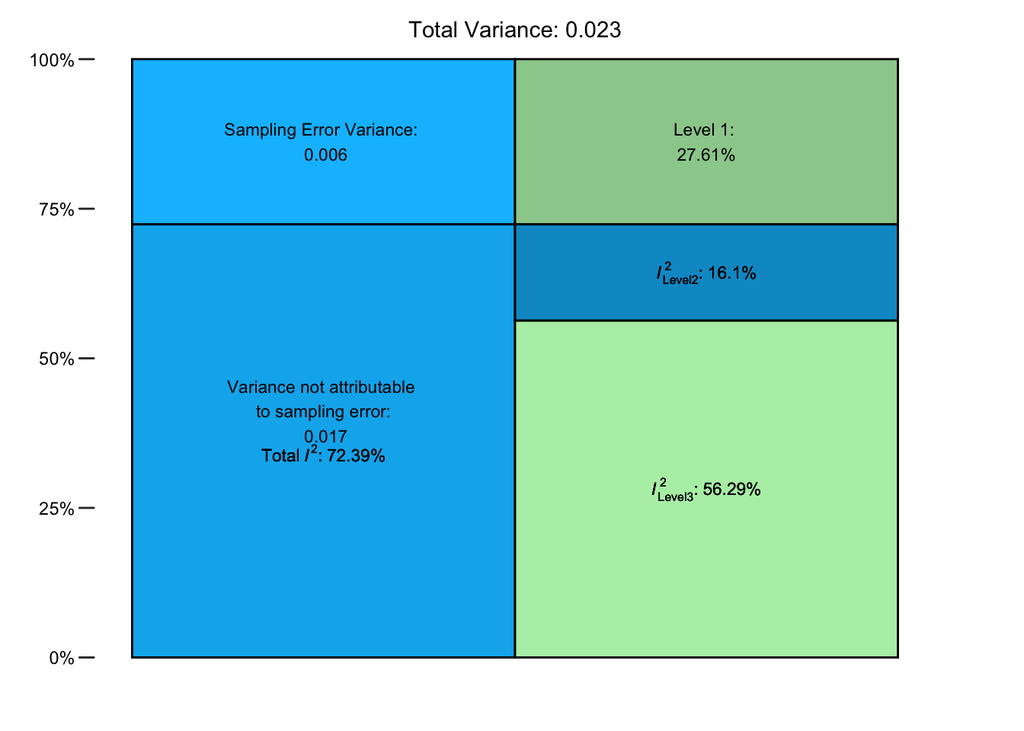

```r
i2 <- var.comp(full.model)

plot(i2)
```

In our case, roughly 72.39% of the variation between effect sizes can be attributed to within-study (16.1% of the total variation) or between-study heterogeneity (56.29%). The remaining variance has been attributed to sampling error. This *I*<sup>2</sup> value is considered to represent a substantial amount of heterogeneity.

### Comparing Models

```r
l3.removed <- rma.mv(yi = z_psyc_coop,
                     V = var_z_psyc_coop,
                     slab = Study,
                     data = PDG,
                     random = ~ 1 | Study/Effect_size_ID,
                     test = "t",
                     method = "REML",
                     sigma2 = c(0, NA))

anova(full.model, l3.removed)
```

```
        df      AIC      BIC     AICc  logLik    LRT   pval       QE
Full     3 -22.9802 -18.6782 -22.0913 14.4901               113.2548
Reduced  2 -23.4531 -20.5851 -23.0245 13.7265 1.5271 0.2165 113.2548
```

### Forest Plot of the Model

Note: This plot had to be generated using a simple random-effects meta-analytic model, as there is not a package available in *R* to accommodate the creation of forest plots for multi-level meta-analytic models.

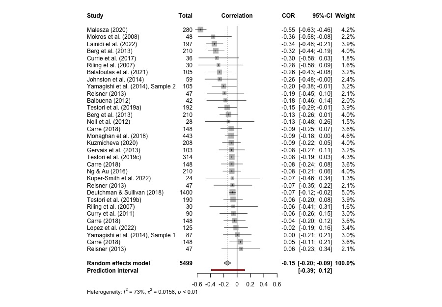

```r
m.cor <- metacor(cor = Psych_Coop,
                 n = n_effect,
                 studlab = Study,
                 data = PDG,
                 fixed = FALSE,
                 random = TRUE,
                 method.tau = "REML",
                 method.random.ci = "HK",
                 title = "Psychopathy and Cooperation in the PDG")

forestplot <- meta::forest(m.cor,
                           sortvar = Psych_Coop,
                           prediction = TRUE,
                           print.tau2 = TRUE,
                           file = "forest.jpeg",
                           width = 900)

knitr::include_graphics("forest.jpeg")
```

## Tests of Publication Bias

In this section, I examined the possibility of publication bias via the visual examination of funnel plots, Egger’s regression test, a simple meta-regression which regressed publication status (as a binary factor) on effect size, and PET-PEESE methods.

### Funnel Plot

While this funnel plot does possess some asymmetry, it should be noted that our *I*<sup>2</sup> value indicated a substantial amount of heterogeneity between effect sizes (i.e., 72.39% of the variation between effect sizes was due to within-study and between-study heterogeneity). Asymmetry in a funnel plot has several possible sources (Page et al., 2020):

- Publication bias and other reporting biases;
- Variability in methodological quality;
- Between-study heterogeneity;
- Artefactual variance (i.e., via the correlation between effect sizes and their standard error)
- Chance

While it is certainly possible that the asymmetry is attributable to publication bias, there are also potential explanations for the phenomenon.

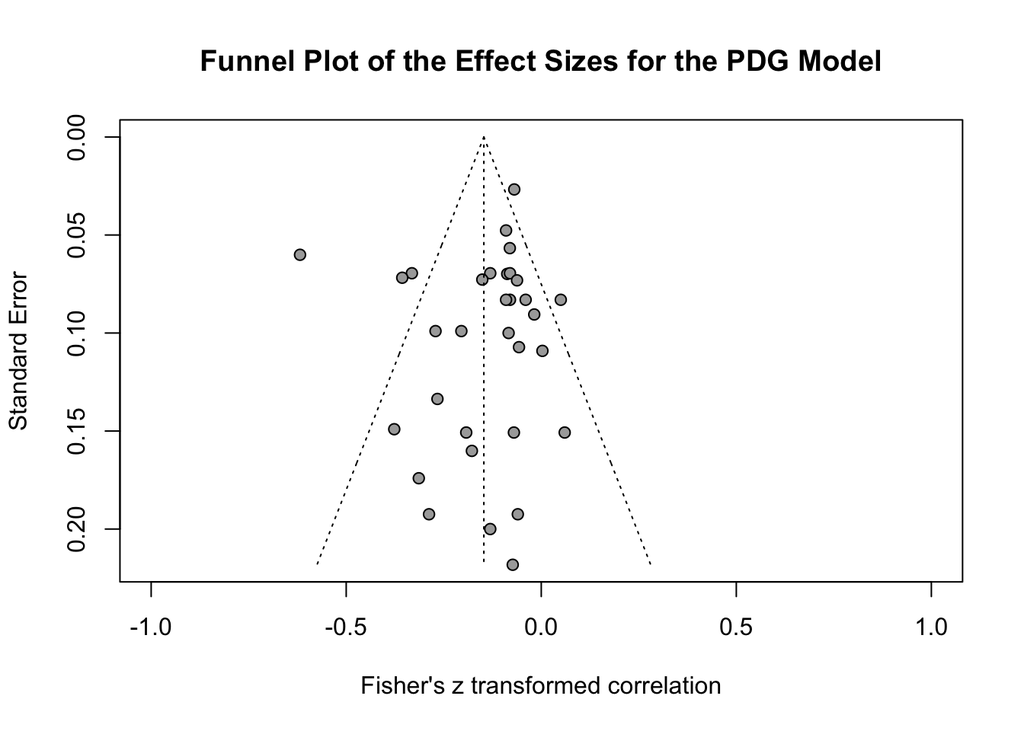

```r
meta::funnel(m.cor,
             xlim = c(-1, 1),
             studlab = FALSE)

title("Funnel Plot of the Effect Sizes for the PDG Model")
```

### Egger’s Regression Test

Egger’s regression test (Egger et al., 1997) is a method that provides a statistical test of asymmetry in a funnel plot. It involves the prediction of standardized effect sizes on their precision.

The intercept (i.e., $\beta_0$) is of primary interest, representing the asymmetry of the plot. NHST can be used to test the null hypothesis that the intercept is equal to zero, indicating symmetry in the funnel plot. Conversely, a rejected null hypothesis for the intercept indicates asymmetry in the funnel plot - potentially due to publication bias.

The slope (i.e., $\beta_1$) represents the effect size adjusted for precision. It is expected to be consistent with the overall meta-analytic effect.

Reported below is the significance test and parameter estimate for the intercept.

```r
metabias(m.cor,
         method.bias = "linreg")
```

```
Review:     Psychopathy and Cooperation in the PDG

Linear regression test of funnel plot asymmetry

Test result: t = -0.67, df = 30, p-value = 0.5054
Bias estimate: -0.4817 (SE = 0.7145)

Details:
- multiplicative residual heterogeneity variance (tau^2 = 3.7188)
- predictor: standard error
- weight:    inverse variance
- reference: Egger et al. (1997), BMJ
```

### Publication Status as a Moderator of Effect Size

Simple meta-regression was used to predict effect sizes from publication status as a factor (i.e., 0 = unpublished, 1 = published).

```r
mod.model.pub <- rma.mv(yi = z_psyc_coop,
                           V = var_z_psyc_coop,
                           slab = Study,
                           data = PDG,
                           random = ~ 1 | Study/Effect_size_ID,
                           test = "t",
                           method = "REML",
                           mods = ~ Publication_Status)

summary(mod.model.pub)
```

```
Multivariate Meta-Analysis Model (k = 32; method: REML)

  logLik  Deviance       AIC       BIC      AICc
 14.5504  -29.1009  -21.1009  -15.4961  -19.5009

Variance Components:

            estim    sqrt  nlvls  fixed                factor
sigma^2.1  0.0115  0.1071     25     no                 Study
sigma^2.2  0.0045  0.0673     32     no  Study/Effect_size_ID

Test for Residual Heterogeneity:
QE(df = 30) = 107.0849, p-val < .0001

Test of Moderators (coefficient 2):
F(df1 = 1, df2 = 30) = 1.3381, p-val = 0.2565

Model Results:

                             estimate      se     tval  df    pval    ci.lb
intrcpt                       -0.0727  0.0795  -0.9145  30  0.3678  -0.2351
Publication_StatusPublished   -0.1000  0.0864  -1.1567  30  0.2565  -0.2765
                              ci.ub
intrcpt                      0.0897
Publication_StatusPublished  0.0765

---
Signif. codes:  0 '***' 0.001 '**' 0.01 '*' 0.05 '.' 0.1 ' ' 1
```

The omnibus test indicates that there is no significant difference between published and unpublished studies, *F*(1, 30) = 1.34, *p* = .257.

### PET & PEESE Analyses

The PET (Precision-Effect Test) and PEESE (Precision-Effect Estimate with Standard Error) are two analytical methods designed to address publication bias in meta-analyses.

The former, PET analysis, is designed to determine the degree to which small-study effects and publication bias impact a meta-analysis. To do so, effect sizes are predicted from their standard errors. This analysis is used to provide evidence that a genuine effect exists beyond the effect of small-study effects/publication bias.

#### PET Analysis

The key element of the PET analysis is the estimate for $\beta_0$ or the intercept of the regression. According to the logic for PET analysis, a non-significant intercept indicates that no genuine effect occurs beyond small-study effects/publication bias. In contrast, a significant intercept provides evidence for a true effect.

That being said, one potential issue with both PET and PEESE analysis is the assumption that there is a homogenous distribution underlying effect sizes. Conceptually, this is similar to the assumption underlying fixed-effects meta-analyses (https://willgervais.com/blog/2015/6/25/putting-pet-peese-to-the-test-1). While this is problematic in and of itself, we will proceed using the PET-PEESE method.

```r
pet_model <- rma.mv(yi = z_psyc_coop,
                     V = var_z_psyc_coop,
                    mods = ~ z_se_psyc_coop,
                     slab = Study,
                     data = PDG,
                     random = ~ 1 | Study/Effect_size_ID,
                     test = "t",
                     method = "REML")

summary(pet_model)
```

```
Multivariate Meta-Analysis Model (k = 32; method: REML)

  logLik  Deviance       AIC       BIC      AICc
 13.8169  -27.6338  -19.6338  -14.0290  -18.0338

Variance Components:

            estim    sqrt  nlvls  fixed                factor
sigma^2.1  0.0138  0.1173     25     no                 Study
sigma^2.2  0.0036  0.0599     32     no  Study/Effect_size_ID

Test for Residual Heterogeneity:
QE(df = 30) = 111.5646, p-val < .0001

Test of Moderators (coefficient 2):
F(df1 = 1, df2 = 30) = 0.0126, p-val = 0.9113

Model Results:

                estimate      se     tval  df    pval    ci.lb   ci.ub
intrcpt          -0.1503  0.0757  -1.9858  30  0.0563  -0.3049  0.0043  .
z_se_psyc_coop   -0.0821  0.7307  -0.1123  30  0.9113  -1.5744  1.4103

---
Signif. codes:  0 '***' 0.001 '**' 0.01 '*' 0.05 '.' 0.1 ' ' 1
```

#### PEESE Analysis

PEESE analysis aims to produce a precise estimate of the true effect size after accounting for sampling error, small-study effects, and publication bias. It does so by creating a regression where effect sizes are predicted by the squared standard errors of studies.

Again, the primary parameter estimate of interest is $\beta_0$, which indicates the estimate of the true effect size (after adjusting for sampling error, small-study effects, and publication bias). Significance tests are interpreted such that a significant intercept indicates a significant meta-analytic effect size.

A secondary parameter estimate of interest is $\beta_1$, which indicates the relationship between effect sizes and their variances. When this is significant, there is evidence that effect sizes are systematically related to the estimate of their precision (i.e., their variance), which may suggest the presence of small-study effects or publication bias.

More particularly, a positive slope indicates that larger variances (with larger standard errors, and, oftentimes, smaller sample sizes) report larger effect sizes. This is representative of the typical “small-study effect” and indicates potential publication bias.

In contrast, a negative slope suggests that smaller studies report smaller effect sizes and larger studies report larger effect sizes. This may indicate other sources of bias or sources of heterogeneity impacting the results.

```r
peese_model <- rma.mv(yi = z_psyc_coop,
                     V = var_z_psyc_coop,
                    mods = ~ var_z_psyc_coop,
                     slab = Study,
                     data = PDG,
                     random = ~ 1 | Study/Effect_size_ID,
                     test = "t",
                     method = "REML")

summary(peese_model)
```

```
Multivariate Meta-Analysis Model (k = 32; method: REML)

  logLik  Deviance       AIC       BIC      AICc
 13.8805  -27.7609  -19.7609  -14.1562  -18.1609

Variance Components:

            estim    sqrt  nlvls  fixed                factor
sigma^2.1  0.0137  0.1169     25     no                 Study
sigma^2.2  0.0036  0.0599     32     no  Study/Effect_size_ID

Test for Residual Heterogeneity:
QE(df = 30) = 112.6455, p-val < .0001

Test of Moderators (coefficient 2):
F(df1 = 1, df2 = 30) = 0.0075, p-val = 0.9316

Model Results:

                 estimate      se     tval  df    pval    ci.lb    ci.ub
intrcpt           -0.1551  0.0461  -3.3678  30  0.0021  -0.2492  -0.0611  **
var_z_psyc_coop   -0.2663  3.0782  -0.0865  30  0.9316  -6.5529   6.0204

---
Signif. codes:  0 '***' 0.001 '**' 0.01 '*' 0.05 '.' 0.1 ' ' 1
```

```r
convert_z2r(-.1551)
```

```
[1] -0.1538682
```

The slope coefficient indicates a non-significant, negative relationship between effect sizes and their variances (see above). The fact that this relationship is not significant indicates that publication bias does not have a substantial impact on the effect sizes.

To illustrate the slope estimated by the model visually, we will plot the regression.

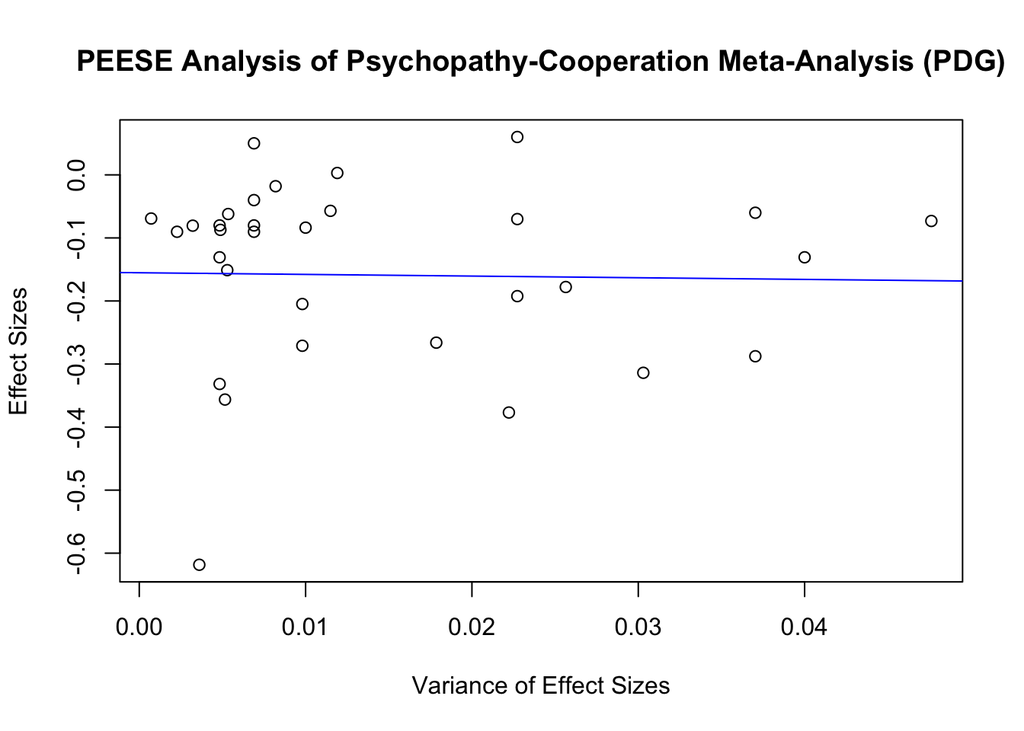

```r
plot(
  PDG$var_z_psyc_coop, PDG$z_psyc_coop,
  xlab = "Variance of Effect Sizes",
  ylab = "Effect Sizes",
  main = "PEESE Analysis of Psychopathy-Cooperation Meta-Analysis (PDG)"
)
abline(a = coef(peese_model)[1], b = coef(peese_model)[2], col = "blue")
```

### Fail-Safe *N*

A variation of Orwin’s (1983) fail-safe N test was used to indicate the number of studies with null effects needed to reduce the effect size to a practically irrelevant size (Viechtbauer, 2010). Practical insignificance was demarked by an effect size of r = |.05|, depending on the direction of the summary effect.

```r
fail.safe <- rma(yi = z_psyc_coop,
                 vi = var_z_psyc_coop,
                 slab = Study,
                 data = PDG,
                 test = "t",
                 method = "REML")

fsn(fail.safe, type = "General", target = 0.05)
```

```
Fail-safe N Calculation Using the General Approach

Average Effect Size:         -0.1472 (with file drawer: -0.0501)
Amount of Heterogeneity:      0.0158 (with file drawer:  0.0200)
Observed Significance Level:  <.0001 (with file drawer:  0.0071)
Target Effect Size:          -0.0500

Fail-safe N: 53
```

## Moderator Analysis

Afterwards, a series of moderators were tested. The list of moderators was generated *a priori* using the Affordance-Based Framework of Prosocial Behavior, original ideas, and ideas from previous meta-analyses on psychopathy and cooperation (e.g., Thielmann et al., 2020). In-depth reasoning for the selection of moderators is provided in the dissertation package.

Multiple meta-regression was not used in our study due to constraints arising from (a) a smaller numbers of studies being used (b) the large number of moderators being considered (Higgins & Thompson, 2004). As such, our study explored individual moderators with simple meta-regression analysis. For each model where there were over 10 studies (Deeks et al., 2023), moderators of interest were examined individually using simple meta-regression.

As the current model had 32 effect sizes, simple meta-regression was used to test the list of moderators. The results are shown below.

### *N* as a Moderator of Effect Size

```r
mod.model.n <- rma.mv(yi = z_psyc_coop,
                    V = var_z_psyc_coop,
                    slab = Study,
                    data = PDG,
                    random = ~ 1 | Study/Effect_size_ID,
                    test = "t",
                    method = "REML",
                    mods = ~ n_effect)

summary(mod.model.n)
```

```
Multivariate Meta-Analysis Model (k = 32; method: REML)

  logLik  Deviance       AIC       BIC      AICc
 13.5949  -27.1899  -19.1899  -13.5851  -17.5899

Variance Components:

            estim    sqrt  nlvls  fixed                factor
sigma^2.1  0.0139  0.1178     25     no                 Study
sigma^2.2  0.0036  0.0599     32     no  Study/Effect_size_ID

Test for Residual Heterogeneity:
QE(df = 30) = 106.0540, p-val < .0001

Test of Moderators (coefficient 2):
F(df1 = 1, df2 = 30) = 0.2707, p-val = 0.6067

Model Results:

          estimate      se     tval  df    pval    ci.lb    ci.ub
intrcpt    -0.1708  0.0406  -4.2096  30  0.0002  -0.2537  -0.0879  ***
n_effect    0.0001  0.0001   0.5203  30  0.6067  -0.0002   0.0003

---
Signif. codes:  0 '***' 0.001 '**' 0.01 '*' 0.05 '.' 0.1 ' ' 1
```

### Sex Composition as a Moderator of Effect Size

Note: sex composition was a variable represented as the proportion of participants who identified as female in the study.

```r
mod.model.sex <- rma.mv(yi = z_psyc_coop,
                             V = var_z_psyc_coop,
                             slab = Study,
                             data = PDG,
                             random = ~ 1 | Study/Effect_size_ID,
                             test = "t",
                             method = "REML",
                             mods = ~ Sex_female)
summary(mod.model.sex)
```

```
Multivariate Meta-Analysis Model (k = 31; method: REML)

  logLik  Deviance       AIC       BIC      AICc
 12.9446  -25.8891  -17.8891  -12.4199  -16.2225

Variance Components:

            estim    sqrt  nlvls  fixed                factor
sigma^2.1  0.0146  0.1208     24     no                 Study
sigma^2.2  0.0037  0.0608     31     no  Study/Effect_size_ID

Test for Residual Heterogeneity:
QE(df = 29) = 111.6339, p-val < .0001

Test of Moderators (coefficient 2):
F(df1 = 1, df2 = 29) = 0.1567, p-val = 0.6951

Model Results:

            estimate      se     tval  df    pval    ci.lb    ci.ub
intrcpt      -0.1857  0.0690  -2.6919  29  0.0117  -0.3268  -0.0446  *
Sex_female    0.0526  0.1328   0.3959  29  0.6951  -0.2190   0.3241

---
Signif. codes:  0 '***' 0.001 '**' 0.01 '*' 0.05 '.' 0.1 ' ' 1
```

### Mean Age as a Moderator of Effect Size

```r
mod.model.age <- rma.mv(yi = z_psyc_coop,
                        V = var_z_psyc_coop,
                        slab = Study,
                        data = PDG,
                        random = ~ 1 | Study/Effect_size_ID,
                        test = "t",
                        method = "REML",
                        mods = ~ Age)
summary(mod.model.age)
```

```
Multivariate Meta-Analysis Model (k = 29; method: REML)

  logLik  Deviance       AIC       BIC      AICc
 12.2853  -24.5706  -16.5706  -11.3872  -14.7524

Variance Components:

            estim    sqrt  nlvls  fixed                factor
sigma^2.1  0.0143  0.1194     22     no                 Study
sigma^2.2  0.0038  0.0616     29     no  Study/Effect_size_ID

Test for Residual Heterogeneity:
QE(df = 27) = 108.7663, p-val < .0001

Test of Moderators (coefficient 2):
F(df1 = 1, df2 = 27) = 1.2723, p-val = 0.2693

Model Results:

         estimate      se     tval  df    pval    ci.lb   ci.ub
intrcpt   -0.0289  0.1270  -0.2277  27  0.8216  -0.2895  0.2317
Age       -0.0051  0.0045  -1.1279  27  0.2693  -0.0143  0.0042

---
Signif. codes:  0 '***' 0.001 '**' 0.01 '*' 0.05 '.' 0.1 ' ' 1
```

### Sample Source as a Moderator of Effect Size

Note: Studies were coded such that:

- 0 = Community;
- 1 = Student;
- 2 = Inmate;
- 3 = Mixed

```r
mod.model.sample <- rma.mv(yi = z_psyc_coop,
                        V = var_z_psyc_coop,
                        slab = Study,
                        data = PDG,
                        random = ~ 1 | Study/Effect_size_ID,
                        test = "t",
                        method = "REML",
                        mods = ~ Sample_Source)
summary(mod.model.sample)
```

```
Multivariate Meta-Analysis Model (k = 31; method: REML)

  logLik  Deviance       AIC       BIC      AICc
 12.4242  -24.8484  -12.8484   -5.0734   -8.6484

Variance Components:

            estim    sqrt  nlvls  fixed                factor
sigma^2.1  0.0144  0.1202     24     no                 Study
sigma^2.2  0.0036  0.0601     31     no  Study/Effect_size_ID

Test for Residual Heterogeneity:
QE(df = 27) = 107.6302, p-val < .0001

Test of Moderators (coefficients 2:4):
F(df1 = 3, df2 = 27) = 0.6368, p-val = 0.5979

Model Results:

                      estimate      se     tval  df    pval    ci.lb    ci.ub
intrcpt                -0.1742  0.0461  -3.7768  27  0.0008  -0.2689  -0.0796
Sample_SourceStudent    0.0526  0.0707   0.7430  27  0.4639  -0.0926   0.1977
Sample_SourceInmate    -0.0379  0.1473  -0.2571  27  0.7991  -0.3400   0.2643
Sample_SourceMixed     -0.2027  0.2059  -0.9841  27  0.3338  -0.6252   0.2199

intrcpt               ***
Sample_SourceStudent
Sample_SourceInmate
Sample_SourceMixed

---
Signif. codes:  0 '***' 0.001 '**' 0.01 '*' 0.05 '.' 0.1 ' ' 1
```

### Psychopathy Measure as a Moderator of Effect Size

Note: Studies were coded such that:

- 0 = SRP;
- 1 = PCL;
- 2 = PPI;
- 3 = LSRP;
- 4 = TriPM;
- 5 = SD3;
- 6 = DD

```r
mod.model.measure <- rma.mv(yi = z_psyc_coop,
                        V = var_z_psyc_coop,
                        slab = Study,
                        data = PDG,
                        random = ~ 1 | Study/Effect_size_ID,
                        test = "t",
                        method = "REML",
                        mods = ~ Measure_coded)
summary(mod.model.measure)
```

```
Multivariate Meta-Analysis Model (k = 31; method: REML)

  logLik  Deviance       AIC       BIC      AICc
 10.6696  -21.3392   -3.3392    7.2633    9.5179

Variance Components:

            estim    sqrt  nlvls  fixed                factor
sigma^2.1  0.0096  0.0979     24     no                 Study
sigma^2.2  0.0069  0.0828     31     no  Study/Effect_size_ID

Test for Residual Heterogeneity:
QE(df = 24) = 76.5938, p-val < .0001

Test of Moderators (coefficients 2:7):
F(df1 = 6, df2 = 24) = 0.7936, p-val = 0.5840

Model Results:

                    estimate      se     tval  df    pval    ci.lb    ci.ub
intrcpt              -0.2837  0.0804  -3.5275  24  0.0017  -0.4496  -0.1177  **
Measure_codedPCL      0.2105  0.2656   0.7928  24  0.4357  -0.3376   0.7587
Measure_codedPPI      0.1256  0.0999   1.2572  24  0.2208  -0.0806   0.3319
Measure_codedLSRP     0.1184  0.0957   1.2382  24  0.2276  -0.0790   0.3159
Measure_codedTriPM    0.2031  0.1616   1.2565  24  0.2210  -0.1305   0.5367
Measure_codedSD3      0.1902  0.0927   2.0516  24  0.0513  -0.0011   0.3815   .
Measure_codedDD       0.1196  0.1188   1.0063  24  0.3243  -0.1257   0.3648

---
Signif. codes:  0 '***' 0.001 '**' 0.01 '*' 0.05 '.' 0.1 ' ' 1
```

### One-Shot vs. Iterated as a Moderator of Effect Size

Note: Studies were coded such that:

- 0 = one-shot;
- 1 = iterated

```r
mod.model.iterated <- rma.mv(yi = z_psyc_coop,
                            V = var_z_psyc_coop,
                            slab = Study,
                            data = PDG,
                            random = ~ 1 | Study/Effect_size_ID,
                            test = "t",
                            method = "REML",
                            mods = ~ Iterated)

summary(mod.model.iterated)
```

```
Multivariate Meta-Analysis Model (k = 32; method: REML)

  logLik  Deviance       AIC       BIC      AICc
 15.2178  -30.4357  -22.4357  -16.8309  -20.8357

Variance Components:

            estim    sqrt  nlvls  fixed                factor
sigma^2.1  0.0107  0.1035     25     no                 Study
sigma^2.2  0.0039  0.0626     32     no  Study/Effect_size_ID

Test for Residual Heterogeneity:
QE(df = 30) = 90.4976, p-val < .0001

Test of Moderators (coefficient 2):
F(df1 = 1, df2 = 30) = 3.2495, p-val = 0.0815

Model Results:

                  estimate      se     tval  df    pval    ci.lb    ci.ub
intrcpt            -0.1087  0.0405  -2.6862  30  0.0117  -0.1914  -0.0261  *
IteratedIterated   -0.1097  0.0609  -1.8026  30  0.0815  -0.2340   0.0146  .

---
Signif. codes:  0 '***' 0.001 '**' 0.01 '*' 0.05 '.' 0.1 ' ' 1
```

### Perceived Opponent as a Moderator of Effect Size

Note: Studies were coded such that:

- 0 = participants were *not* led to believe that their opponent was human;
- 1 = participants *were* led to believe that their opponent was human

```r
mod.model.perceive <- rma.mv(yi = z_psyc_coop,
                             V = var_z_psyc_coop,
                             slab = Study,
                             data = PDG,
                             random = ~ 1 | Study/Effect_size_ID,
                             test = "t",
                             method = "REML",
                             mods = ~ Perceived_Opponent)
summary(mod.model.perceive)
```

```
Multivariate Meta-Analysis Model (k = 31; method: REML)

  logLik  Deviance       AIC       BIC      AICc
 13.6107  -27.2215  -19.2215  -13.7523  -17.5548

Variance Components:

            estim    sqrt  nlvls  fixed                factor
sigma^2.1  0.0128  0.1131     24     no                 Study
sigma^2.2  0.0041  0.0643     31     no  Study/Effect_size_ID

Test for Residual Heterogeneity:
QE(df = 29) = 102.5199, p-val < .0001

Test of Moderators (coefficient 2):
F(df1 = 1, df2 = 29) = 1.8050, p-val = 0.1895

Model Results:

                       estimate      se     tval  df    pval    ci.lb    ci.ub
intrcpt                 -0.2452  0.0726  -3.3765  29  0.0021  -0.3937  -0.0967
Perceived_OpponentYes    0.1092  0.0813   1.3435  29  0.1895  -0.0570   0.2754

intrcpt                **
Perceived_OpponentYes

---
Signif. codes:  0 '***' 0.001 '**' 0.01 '*' 0.05 '.' 0.1 ' ' 1
```

### Social Role of Opponent as a Moderator of Effect Size

Note: Studies were coded such that:

- 0 = The participants’ perceived opponent was a close member of their social circle (e.g., friend, in-group member);
- 1 = The participants’ perceived opponent was a distant member of their social circle (e.g., stranger, out-group member)

```r
mod.model.social <- rma.mv(yi = z_psyc_coop,
                             V = var_z_psyc_coop,
                             slab = Study,
                             data = PDG,
                             random = ~ 1 | Study/Effect_size_ID,
                             test = "t",
                             method = "REML",
                             mods = ~ Social_role)
summary(mod.model.social)
```

```
Multivariate Meta-Analysis Model (k = 24; method: REML)

  logLik  Deviance       AIC       BIC      AICc
 12.1772  -24.3543  -16.3543  -11.9901  -14.0014

Variance Components:

            estim    sqrt  nlvls  fixed                factor
sigma^2.1  0.0164  0.1279     19     no                 Study
sigma^2.2  0.0000  0.0000     24     no  Study/Effect_size_ID

Test for Residual Heterogeneity:
QE(df = 22) = 83.4927, p-val < .0001

Test of Moderators (coefficient 2):
F(df1 = 1, df2 = 22) = 2.1092, p-val = 0.1605

Model Results:

                           estimate      se     tval  df    pval    ci.lb
intrcpt                     -0.0359  0.0747  -0.4804  22  0.6357  -0.1907
Social_roleDistant member   -0.1044  0.0719  -1.4523  22  0.1605  -0.2534
                            ci.ub
intrcpt                    0.1190
Social_roleDistant member  0.0447

---
Signif. codes:  0 '***' 0.001 '**' 0.01 '*' 0.05 '.' 0.1 ' ' 1
```

### Incentive Structure as a Moderator of Effect Size

Note: Studies were coded such that:

- 0 = The study was not incentivized;
- 1 = Participation was incentivized;
- 2 = Performance was incentivized

```r
mod.model.incentive <- rma.mv(yi = z_psyc_coop,
                           V = var_z_psyc_coop,
                           slab = Study,
                           data = PDG,
                           random = ~ 1 | Study/Effect_size_ID,
                           test = "t",
                           method = "REML",
                           mods = ~ Incentives)
summary(mod.model.incentive)
```

```
Multivariate Meta-Analysis Model (k = 24; method: REML)

  logLik  Deviance       AIC       BIC      AICc
 11.3223  -22.6446  -12.6446   -7.4219   -8.6446

Variance Components:

            estim    sqrt  nlvls  fixed                factor
sigma^2.1  0.0093  0.0965     20     no                 Study
sigma^2.2  0.0045  0.0674     24     no  Study/Effect_size_ID

Test for Residual Heterogeneity:
QE(df = 21) = 73.7621, p-val < .0001

Test of Moderators (coefficients 2:3):
F(df1 = 2, df2 = 21) = 2.6087, p-val = 0.0973

Model Results:

                                      estimate      se     tval  df    pval
intrcpt                                -0.3029  0.0742  -4.0827  21  0.0005
IncentivesParticipation incentivized    0.1480  0.0910   1.6268  21  0.1187
IncentivesPerformance incentivized      0.2072  0.0909   2.2794  21  0.0332
                                        ci.lb    ci.ub
intrcpt                               -0.4571  -0.1486  ***
IncentivesParticipation incentivized  -0.0412   0.3373
IncentivesPerformance incentivized     0.0182   0.3962    *

---
Signif. codes:  0 '***' 0.001 '**' 0.01 '*' 0.05 '.' 0.1 ' ' 1
```

### *k*-index as a Moderator of Effect Size

Note: The *k*-index indicates the degree to which the payoffs in a game incentivize cooperation or defection in a 2x2 game (e.g., the PDG). The *k*-index is bounded between 0 and 1, with 0 indicating a game where exploitation is heavily incentivized and 1 indicating a game where cooperation is heavily incentivized (Rapoport and Chammah, 1965).

```r
mod.model.k <- rma.mv(yi = z_psyc_coop,
                              V = var_z_psyc_coop,
                              slab = Study,
                              data = PDG,
                              random = ~ 1 | Study/Effect_size_ID,
                              test = "t",
                              method = "REML",
                              mods = ~ K)
summary(mod.model.k)
```

```
Multivariate Meta-Analysis Model (k = 26; method: REML)

  logLik  Deviance       AIC       BIC      AICc
 11.4521  -22.9042  -14.9042  -10.1920  -12.7989

Variance Components:

            estim    sqrt  nlvls  fixed                factor
sigma^2.1  0.0190  0.1379     20     no                 Study
sigma^2.2  0.0000  0.0000     26     no  Study/Effect_size_ID

Test for Residual Heterogeneity:
QE(df = 24) = 86.8666, p-val < .0001

Test of Moderators (coefficient 2):
F(df1 = 1, df2 = 24) = 1.5060, p-val = 0.2317

Model Results:

         estimate      se     tval  df    pval    ci.lb   ci.ub
intrcpt   -0.0314  0.1038  -0.3030  24  0.7645  -0.2456  0.1827
K         -0.2967  0.2418  -1.2272  24  0.2317  -0.7957  0.2023

---
Signif. codes:  0 '***' 0.001 '**' 0.01 '*' 0.05 '.' 0.1 ' ' 1
```

### Feedback as a Moderator of Effect Size

Note: Studies were coded such that:

- 0 = Participants did not receive feedback on their choices (i.e., what their opponent chose to do, what the outcome was);
- 1 = Participants did receive feedback on their choices

```r
mod.model.feedback <- rma.mv(yi = z_psyc_coop,
                      V = var_z_psyc_coop,
                      slab = Study,
                      data = PDG,
                      random = ~ 1 | Study/Effect_size_ID,
                      test = "t",
                      method = "REML",
                      mods = ~ Feedback)
summary(mod.model.feedback)
```

```
Multivariate Meta-Analysis Model (k = 24; method: REML)

  logLik  Deviance       AIC       BIC      AICc
 11.5307  -23.0614  -15.0614  -10.6972  -12.7085

Variance Components:

            estim    sqrt  nlvls  fixed                factor
sigma^2.1  0.0169  0.1301     18     no                 Study
sigma^2.2  0.0000  0.0000     24     no  Study/Effect_size_ID

Test for Residual Heterogeneity:
QE(df = 22) = 69.4959, p-val < .0001

Test of Moderators (coefficient 2):
F(df1 = 1, df2 = 22) = 4.3850, p-val = 0.0480

Model Results:

                  estimate      se     tval  df    pval    ci.lb    ci.ub
intrcpt            -0.0745  0.0562  -1.3254  22  0.1986  -0.1911   0.0421
FeedbackFeedback   -0.1593  0.0761  -2.0940  22  0.0480  -0.3172  -0.0015  *

---
Signif. codes:  0 '***' 0.001 '**' 0.01 '*' 0.05 '.' 0.1 ' ' 1
```

### Opponent Strategy as a Moderator of Effect Size

Note: Studies were coded such that:

- 0 = Live opponent;
- 1 = TFT;
- 2 = TF2T;
- 3 = Neutral/SeeSaw;
- 4 = Random;
- 5 = Replicator

```r
mod.model.strategy <- rma.mv(yi = z_psyc_coop,
                             V = var_z_psyc_coop,
                             slab = Study,
                             data = PDG,
                             random = ~ 1 | Study/Effect_size_ID,
                             test = "t",
                             method = "REML",
                             mods = ~ Strategy)
summary(mod.model.strategy)
```

```
Multivariate Meta-Analysis Model (k = 23; method: REML)

  logLik  Deviance       AIC       BIC      AICc
 16.5868  -33.1736  -19.1736  -12.9410   -7.9736

Variance Components:

            estim    sqrt  nlvls  fixed                factor
sigma^2.1  0.0000  0.0000     17     no                 Study
sigma^2.2  0.0000  0.0000     23     no  Study/Effect_size_ID

Test for Residual Heterogeneity:
QE(df = 18) = 12.4814, p-val = 0.8214

Test of Moderators (coefficients 2:5):
F(df1 = 4, df2 = 18) = 3.9865, p-val = 0.0173

Model Results:

                        estimate      se     tval  df    pval    ci.lb    ci.ub
intrcpt                  -0.0677  0.0269  -2.5175  18  0.0215  -0.1241  -0.0112
StrategyTFT              -0.0695  0.0697  -0.9975  18  0.3317  -0.2159   0.0769
StrategyTF2T             -0.0619  0.0498  -1.2437  18  0.2296  -0.1665   0.0427
StrategyNeutral/Seesaw   -0.2463  0.1761  -1.3980  18  0.1791  -0.6163   0.1238
StrategyReplicator       -0.2887  0.0767  -3.7657  18  0.0014  -0.4497  -0.1276

intrcpt                  *
StrategyTFT
StrategyTF2T
StrategyNeutral/Seesaw
StrategyReplicator      **

---
Signif. codes:  0 '***' 0.001 '**' 0.01 '*' 0.05 '.' 0.1 ' ' 1
```

### Opponent Leniency as a Moderator of Effect Size

Note: Studies were coded such that:

- 0 = Lenient (e.g., Always Cooperate, TF2T, TF3T);
- 1 = Neutral (e.g., TFT, Win-Stay, Lose-Shift);
- 2 = Harsh (e.g., Always Defect, Grim, 2TFT)

```r
mod.model.leniency <- rma.mv(yi = z_psyc_coop,
                             V = var_z_psyc_coop,
                             slab = Study,
                             data = PDG,
                             random = ~ 1 | Study/Effect_size_ID,
                             test = "t",
                             method = "REML",
                             mods = ~ Leniency)
summary(mod.model.leniency)
```

```
Multivariate Meta-Analysis Model (k = 11; method: REML)

  logLik  Deviance       AIC       BIC      AICc
  5.0448  -10.0895   -2.0895   -1.3006    7.9105

Variance Components:

            estim    sqrt  nlvls  fixed                factor
sigma^2.1  0.0010  0.0320      8     no                 Study
sigma^2.2  0.0000  0.0000     11     no  Study/Effect_size_ID

Test for Residual Heterogeneity:
QE(df = 9) = 8.2409, p-val = 0.5101

Test of Moderators (coefficient 2):
F(df1 = 1, df2 = 9) = 0.1177, p-val = 0.7394

Model Results:

                 estimate      se     tval  df    pval    ci.lb    ci.ub
intrcpt           -0.1351  0.0466  -2.9010   9  0.0176  -0.2404  -0.0297  *
LeniencyNeutral   -0.0269  0.0783  -0.3431   9  0.7394  -0.2040   0.1503

---
Signif. codes:  0 '***' 0.001 '**' 0.01 '*' 0.05 '.' 0.1 ' ' 1
```